####*Objective 6. Perform unsupervised clustering of expression data*

Packages used in this notebook: `limma`, `RColorBrewer`. First verify that they are installed and loaded.

Set the directory where you want the results to be stored (this assumes that you have a folder called *RNAseq* on your desktop, with a subfolder called *Results*).

```r
## if you ARE using an R notebook (if not the comment out this line):
knitr::opts_knit$set(root.dir = "~/Desktop/RNAseq/Results/")

## if you ARE NOT using an R notebook (un-comment this line):
#setwd("~/Desktop/RNAseq/Results/")
```

Now we will visualize differences between groups of samples. If it appears that there is some clustering of samples, then doing differential expression analysis can follow to formally test these differences.

We’ll start by assigning different colors to each group of samples (LP, ML, and Basal) in a similar way to what we did in Objective 4.

```r
grps <- dge_sub$samples$group
col.grp <- grps
levels(col.grp) <-  brewer.pal(nlevels(col.grp), "Set1")
col.grp <- as.character(col.grp)
col.grp
```

```
[1] "#377EB8" "#4DAF4A" "#E41A1C" "#E41A1C" "#4DAF4A" "#377EB8" "#E41A1C" "#4DAF4A" "#377EB8"
```

```r
grps
```

```
[1] LP    ML    Basal Basal ML    LP    Basal ML    LP
Levels: Basal LP ML
```

The `plotMDS()` function from the `limma` package shows us a scatterplot where distances between samples represent typical log2(Fold-Change) between the samples for genes that distinguis the samples (see Details in Help file and in Ritchie ME, Phipson B, Wu D, et al., Nucelic Acids Research 2015). MDS=Multidimensional scaling. You can see variance within and between samples or batches.

Let’s save this plot in a .png file too (can use the `png()` function followed by the plot commands and then `dev.off()`, or you can save it directly from the Plots tab in RStudio).

```r
?plotMDS

head(log2cpm_norm)
```

```
        Samples
Tags     GSM1545535_10_6_5_11 GSM1545536_9_6_5_11 GSM1545538_purep53 GSM1545539_JMS8-2 GSM1545540_JMS8-3
  497097            -3.682849           -3.342380           2.530030          3.305434         -3.604114
  27395              3.876035            4.401011           4.521782          4.571100          4.323927
  18777              4.707559            5.558637           5.400160          5.170996          5.627271
  21399              4.784249            4.742007           5.374161          5.130725          4.848287
  58175              3.944469            3.297694          -1.604617         -1.709020          2.998454
  108664             5.866091            6.195228           5.137082          5.277839          6.135591
        Samples
Tags     GSM1545541_JMS8-4 GSM1545542_JMS8-5 GSM1545544_JMS9-P7c GSM1545545_JMS9-P8c
  497097         -3.356367          3.310211           -2.936789           -4.509560
  27395           3.788577          3.920562            4.345597            4.132562
  18777           5.081661          5.079918            5.756374            5.149591
  21399           4.944039          5.158071            5.036287            4.986888
  58175           3.360673         -1.913747            3.144629            3.523965
  108664          6.023874          4.999788            6.216958            6.000949
```

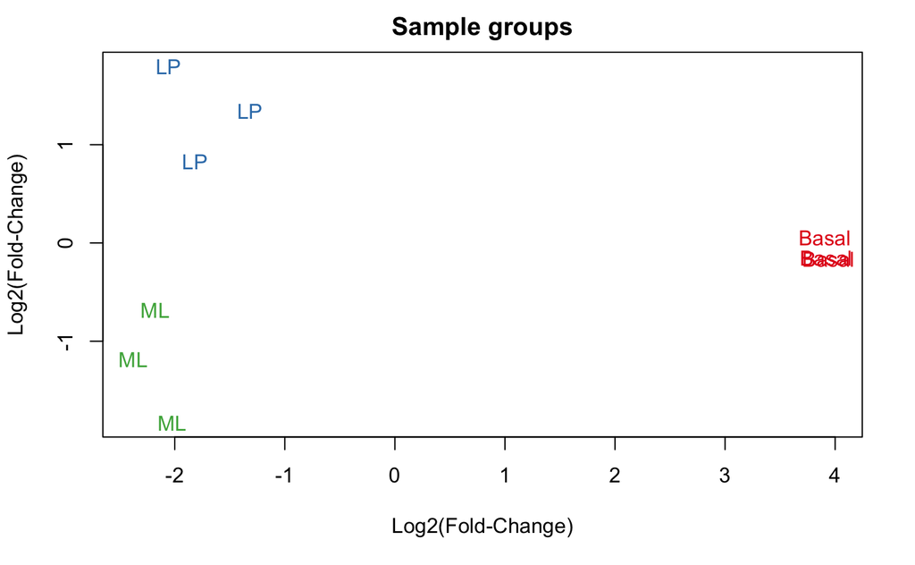

```r
#png("MDSplot.png")
par(mfrow=c(1,1))
plotMDS(log2cpm_norm,
    labels=grps,
    col=col.grp,
    xlab="Log2(Fold-Change)",
    ylab="Log2(Fold-Change)")
title(main="Sample groups")
```

```r
#dev.off()
```

**Discussion:** What is this plot telling us?